# intro_to_tensorflow

```python
import pandas as pd
import numpy as np
import matplotlib as mpl
import matplotlib.pyplot as plt
import seaborn as sns
from matplotlib import rc

rc('text', usetex=True)
rc('text.latex', preamble=r'\usepackage{cmbright}')
rc('font', **{'family': 'sans-serif', 'sans-serif': ['Helvetica']})

%matplotlib inline

# This enables SVG graphics inline.
%config InlineBackend.figure_formats = {'png', 'retina'}

rc = {'lines.linewidth': 2,
      'axes.labelsize': 18,
      'axes.titlesize': 18,
      'axes.facecolor': 'DFDFE5'}
sns.set_context('notebook', rc=rc)
sns.set_style("dark")

mpl.rcParams['xtick.labelsize'] = 16
mpl.rcParams['ytick.labelsize'] = 16
mpl.rcParams['legend.fontsize'] = 14
```

## Data Exploration

In all of this following blog post, I have tried to be explicit about what chatgpt wrote and what I wrote. I think it's likely going to be important for us to cite chatGPT (science, people!), but also to try to train ourselves to notice common errors or discrepancies between the way a person would solve a problem and the way a foundation model would solve it.

```python
# chatgpt suggested:
url = "https://archive.ics.uci.edu/ml/machine-learning-databases/breast-cancer-wisconsin/wdbc.data"
data = pd.read_csv(url, header=None)

# The first column is an ID (we can ignore this), the second column is the label (M = malignant, B = benign),
# and the rest are features
labels = data.iloc[:, 1]
features = data.iloc[:, 2:]
```

```python
# chat suggested:
## Preview the data
#print(features.head())
#print(labels.head())

# i preferred:
print(data[1].unique())
data.head(1)
```

```
['M' 'B']
```

|  | 0 | 1 | 2 | 3 | 4 | 5 | 6 | 7 | 8 | 9 | ... | 22 | 23 | 24 | 25 | 26 | 27 | 28 | 29 | 30 | 31 |
| --- | --- | --- | --- | --- | --- | --- | --- | --- | --- | --- | --- | --- | --- | --- | --- | --- | --- | --- | --- | --- | --- |
| 0 | 842302 | M | 17.99 | 10.38 | 122.8 | 1001.0 | 0.1184 | 0.2776 | 0.3001 | 0.1471 | ... | 25.38 | 17.33 | 184.6 | 2019.0 | 0.1622 | 0.6656 | 0.7119 | 0.2654 | 0.4601 | 0.1189 |

1 rows × 32 columns

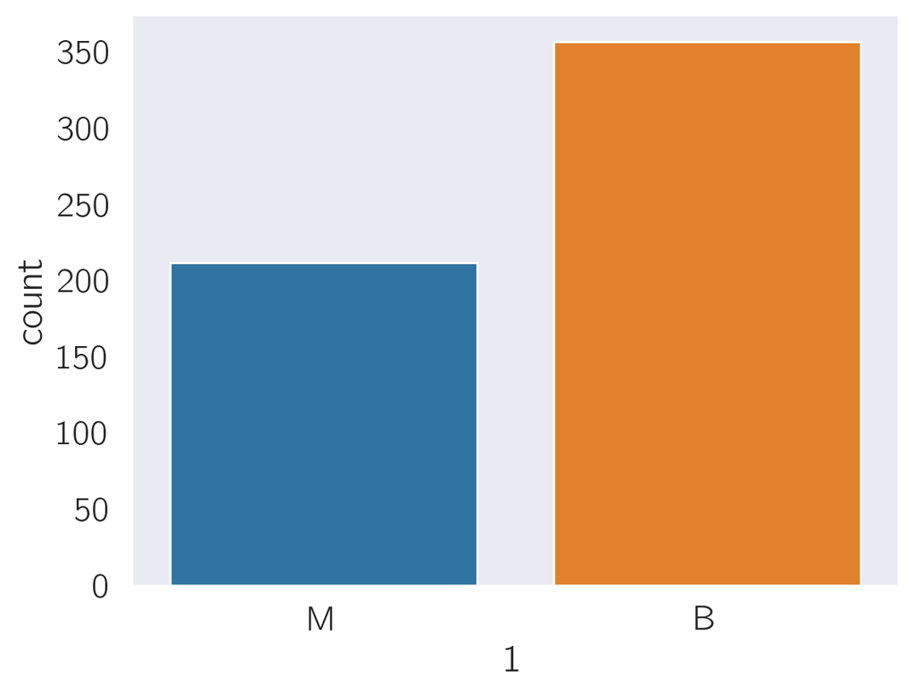

```python
# chat suggested:
# sns.countplot(labels), which did not work.
# upon prompting, chat suggested the following
# line, which DID work:
sns.countplot(x=labels)
```

```python
# chat wrote everything in the next few cells:
from sklearn.preprocessing import LabelEncoder

le = LabelEncoder()
labels_encoded = le.fit_transform(labels)
```

```python
from sklearn.preprocessing import StandardScaler

scaler = StandardScaler()
features_scaled = scaler.fit_transform(features)
```

```python
from sklearn.model_selection import train_test_split

features_train, features_test, labels_train, labels_test =\
    train_test_split(features_scaled, labels_encoded,
                     test_size=0.2, random_state=42)
```

# Building the ML code

For this next section, ChatGPT suggested a few lines of code with little to no explanation for their choice. Upon prompting it to explain its choices, it managed to do so quite well. The following code and text is entirely output via ChatGPT:

```python
import tensorflow as tf
from tensorflow.keras.models import Sequential
from tensorflow.keras.layers import Dense
```

```
2023-05-21 02:44:44.645900: I tensorflow/core/platform/cpu_feature_guard.cc:182] This TensorFlow binary is optimized to use available CPU instructions in performance-critical operations.
To enable the following instructions: AVX2 FMA, in other operations, rebuild TensorFlow with the appropriate compiler flags.
```

These lines import the required modules. TensorFlow is a powerful library for numerical computation, particularly well-suited for large-scale ML.

The function `Sequential` specifies linear stacks of layers that you can easily create a neural network model with. `Dense` from `tensorflow.keras.layers` is the regular fully-connected neural network layer.

```python
model = Sequential()
```

This line creates an instance of a Sequential model. This will be our neural network model that we will add layers to. It's called "sequential" because it allows you to build a model layer by layer, in a sequential manner. Each layer has weights that correspond to the layer that follows it.

```python
model.add(
    Dense(1, activation='sigmoid',
          input_shape=(features_train.shape[1],))
    )
```

Above, we are adding a Dense layer to our model. This next layer is fully connected, meaning all the neurons in the previous layer are connected to all the neurons in the following layer.

The arguments passed to the `Dense` function dictate how the layer will be constructed.

- The first argument, `1`, specifies the number of neurons in the layer. **DAVID'S WORDS**: We chose a single neuron since we are building a simple, 1 layer network which outputs a single classification value (`M` or `B`).
- The `activation` argument is used to specify the activation function for the layer. Here we use a `sigmoid` function because it outputs values between 0 and 1, which is perfect for binary classification problems. Other common choices are `relu`, `tanh` and `softmax` (useful for multi-class classification problems).
- The `input_shape` argument specifies the shape of the previous layer or in this case the number of features in our data.

```python
model.compile(loss='binary_crossentropy',
              optimizer='adam',
              metrics=['accuracy']
             )
```

The compile function configures the model for training. It receives three important arguments:

The loss function. This is the objective that the model will try to minimize. It's also called the cost function. For binary classification problems, 'binary_crossentropy' is a common choice. It calculates the cross-entropy loss between true labels and predicted labels, which is a good measure for classification tasks.

The optimizer. This is the algorithm that the model uses to minimize the loss function. There are several optimizers available, but 'adam' is a good default choice. Adam stands for Adaptive Moment Estimation, and it's an algorithm for gradient descent optimization. It's computationally efficient and requires little memory.

The list of metrics. These are the measures of quality that the model will track during training and testing. Since we are working on a binary classification problem, 'accuracy' (the proportion of correct predictions) is a reasonable metric to use.

```python
history = model.fit(features_train, labels_train,
                    epochs=50,
                    validation_split=0.2)
```

**David's words**: This next section is interestign -- ChatGPT cut off at the end, and I had to prompt it to finish. Here is the output:

The fit function is where the training process takes place. It receives the training data and labels, the number of epochs, and the validation split.

- `features_train` and `labels_train` are the input data and the corresponding labels for training.
- `epochs` is the number of times the training process will pass through the entire dataset. Here, we set it to 50.
- `validation_split

I apologize for the abrupt cutoff earlier. Let's continue the explanation.

- `validation_split=0.2` argument in the fit function is used to set aside a fraction of the training data for validation. The value 0.2 means 20% of the training data will be used as validation data. The model will then not train on this data and instead use it to evaluate the loss and any model metrics at the end of each epoch. This helps monitor the model's performance and prevent overfitting on the training data.

## Evaluation Metrics: Is it working?

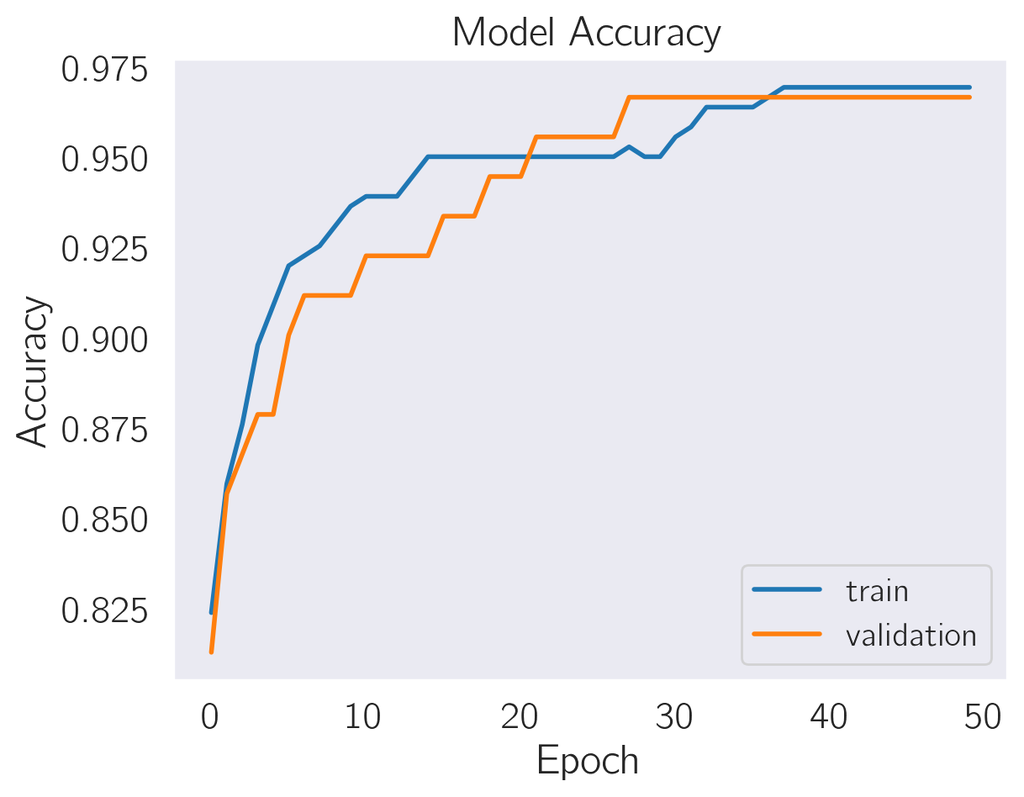

```python
plt.plot(history.history['accuracy'], label='train')
plt.plot(history.history['val_accuracy'], label='validation')
plt.title('Model Accuracy')
plt.ylabel('Accuracy')
plt.xlabel('Epoch')
plt.legend()
```

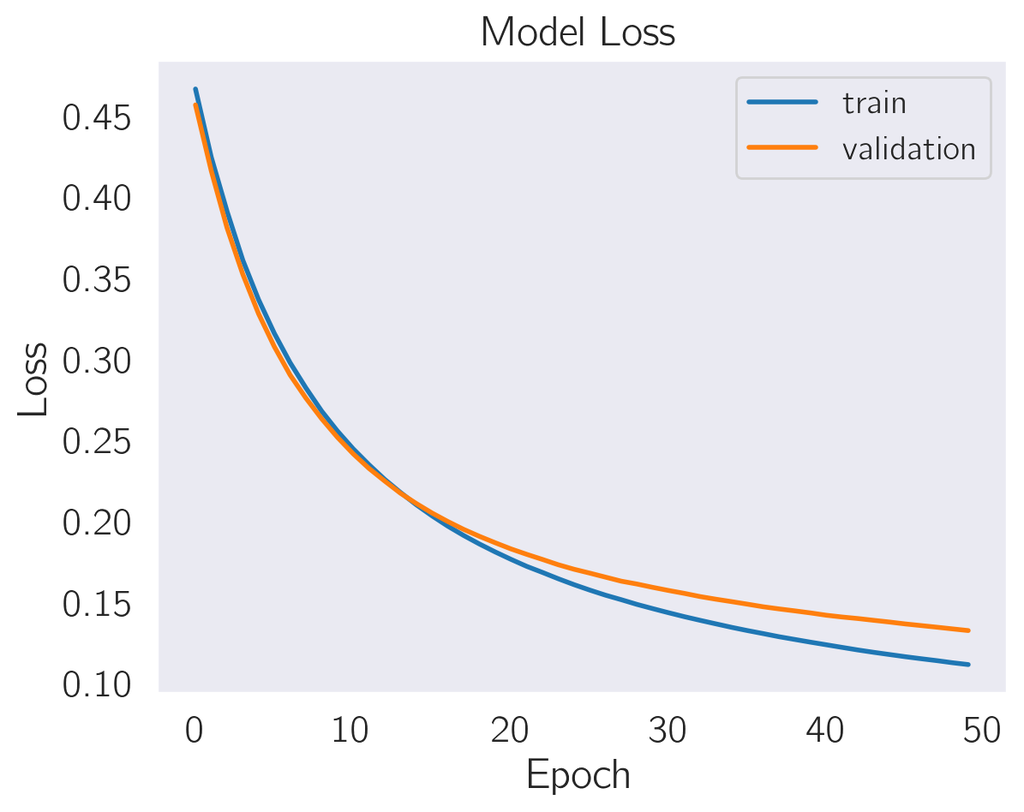

```python
plt.plot(history.history['loss'], label='train')
plt.plot(history.history['val_loss'], label='validation')
plt.title('Model Loss')
plt.ylabel('Loss')
plt.xlabel('Epoch')
plt.legend()
```

```python
loss, accuracy = model.evaluate(features_test, labels_test)
print(f'Test accuracy: {accuracy}')
```

```
Test accuracy: 0.9824561476707458
```